# ANOVA

Neil Stewart

```r
library(tidyverse)
library(gridExtra)
library(emmeans) # for emmeans() and pairs()
library(nycflights13)
library(lubridate)
options(width=100)
```

# Objectives

- Understand analysis of variance (ANOVA)
- Understand the difference between *null hypothesis significance testing* (NHST) and *estimation*
- Understand estimated marginal means
- Understand what an *interaction* is
- Be able to run linear models in R:
  - Using `summary` and `confint`, for the NHST approach
  - Using `emmeans`, for the estimation approach
- Be able to report results in plain English using a NHST or estimation approach
- Be able to produce excellent plots with `ggplot`

# Reading

Howell (2017) Chapters 16 and 17 an excellent introduction to ANOVA

You can find a more advanced treatment in Dalgaard (2008) Chapters 7

# Daily Mean In Air Gain for Flights from NYC

Let’s explore how the average daily in-air gain varies across airports

First we calculate the in-air gain

Then we average over all the flights in one day from one airport

```r
flights <- nycflights13::flights
flights <- mutate(flights, gain=dep_delay-arr_delay) %>% filter (!is.na(gain))
flights.daily <- flights %>% group_by(year,month,day,origin) %>% summarise(gain=mean(gain))
```

## Factors

We are going to make the origin airport into a `factor`. `factor`s are an important *type* in R. Variables for use in `lm()` should either be `numeric` or `factor`s. `character` vectors are coerced into `factor`s. See [Chapter 15 of R for Data Science](https://r4ds.had.co.nz/factors.html)

```r
flights.daily <- mutate(flights.daily, origin=as.factor(origin))
str(pull(flights.daily, origin))
```

```
##  Factor w/ 3 levels "EWR","JFK","LGA": 1 2 3 1 2 3 1 2 3 1 ...
```

```r
flights.daily %>% group_by(origin) %>% summarise(n())
```

```
## # A tibble: 3 x 2
##   origin `n()`
##   <fct>  <int>
## 1 EWR      365
## 2 JFK      365
## 3 LGA      365
```

## One-Way ANOVA

The syntax for running an ANOVA is exactly the same as for a regression. The only difference is that `origin` is a factor not a numerical variable

```r
m.gain.by.origin <- lm(gain~origin, data=flights.daily)
anova(m.gain.by.origin)
```

```
## Analysis of Variance Table
##
## Response: gain
##             Df Sum Sq Mean Sq F value  Pr(>F)
## origin       2    534 267.135  4.4947 0.01138 *
## Residuals 1092  64901  59.433
## ---
## Signif. codes:  0 '***' 0.001 '**' 0.01 '*' 0.05 '.' 0.1 ' ' 1
```

The ANOVA does not tell us where the differences are. The above description of the ANOVA is not sufficient, because it does not say how the airports differ. Which has the largest in-air gain? Which has the smallest?

```r
summary(m.gain.by.origin)
```

```
##
## Call:
## lm(formula = gain ~ origin, data = flights.daily)
##
## Residuals:
##     Min      1Q  Median      3Q     Max
## -35.427  -4.215   0.770   5.037  17.422
##
## Coefficients:
##             Estimate Std. Error t value Pr(>|t|)
## (Intercept)   5.9356     0.4035  14.710   <2e-16 ***
## originJFK     0.4563     0.5707   0.800   0.4241
## originLGA    -1.1999     0.5707  -2.103   0.0357 *
## ---
## Signif. codes:  0 '***' 0.001 '**' 0.01 '*' 0.05 '.' 0.1 ' ' 1
##
## Residual standard error: 7.709 on 1092 degrees of freedom
## Multiple R-squared:  0.008165,   Adjusted R-squared:  0.006348
## F-statistic: 4.495 on 2 and 1092 DF,  p-value: 0.01138
```

The `summary()` function gives us a set of coefficients, just like when we ran a regression. But what do they mean?

## The Design Matrix

Secretly, in the background, R makes a design matrix. Then, to do the ANOVA, R just does a multiple regression. I’ve shown it here so you can see how it works

For example, the coefficient `originJFK` in the `summary()` output is the coefficient for the *dummy variable* `originJFK` in the `model.matrix`. Because EWR is first in the alphabet, it is modelled as the reference airport. The 1 in `originJFK` means that the airport is JFK (and thus not EWR or LGA)

```r
head(cbind(as.data.frame(flights.daily), model.matrix(m.gain.by.origin)))
```

```
##   year month day origin       gain (Intercept) originJFK originLGA
## 1 2013     1   1    EWR -3.5900000           1         0         0
## 2 2013     1   1    JFK  3.9728814           1         1         0
## 3 2013     1   1    LGA -4.6822034           1         0         1
## 4 2013     1   2    EWR -0.3167155           1         0         0
## 5 2013     1   2    JFK  4.9495268           1         1         0
## 6 2013     1   2    LGA -2.0259259           1         0         1
```

| (Intercept) | originJFK | originLGA | Meaning |
| --- | --- | --- | --- |
| 1 | 0 | 0 | means EWR |
| 1 | 1 | 0 | means JFK |
| 1 | 0 | 1 | means LGA |

This means that:

- the intercept 5.9356 is the mean for EWR
- the coefficient 0.4563 for `originJFK` is the difference between EWR and JFK
- the coefficient -1.1999 for `originLGA` is the difference between EWR and LGA

## Estimated Marginal Means

Estimated marginal means are a great way of getting the means for each airport from the model

```r
(  m.gain.by.origin.emm <- emmeans(m.gain.by.origin, ~origin)  )
```

```
##  origin   emmean       SE   df lower.CL upper.CL
##  EWR    5.935624 0.403522 1092 5.143858 6.727390
##  JFK    6.391957 0.403522 1092 5.600191 7.183723
##  LGA    4.735698 0.403522 1092 3.943932 5.527464
##
## Confidence level used: 0.95
```

## Contrasts

We can also make contrasts between these airport means. `pairs()` does all pairwise contrasts

```r
(  m.gain.by.origin.pairs <- confint(pairs(m.gain.by.origin.emm))  )
```

```
##  contrast    estimate        SE   df   lower.CL  upper.CL
##  EWR - JFK -0.4563326 0.5706663 1092 -1.7956330 0.8829679
##  EWR - LGA  1.1999261 0.5706663 1092 -0.1393744 2.5392265
##  JFK - LGA  1.6562586 0.5706663 1092  0.3169582 2.9955591
##
## Confidence level used: 0.95
## Conf-level adjustment: tukey method for comparing a family of 3 estimates
```

## Presenting a One-Way ANOVA

Here is some code for constructing plots of the estimates for each airport and the estimates of the difference between airports, following Cumming’s estimation suggestions

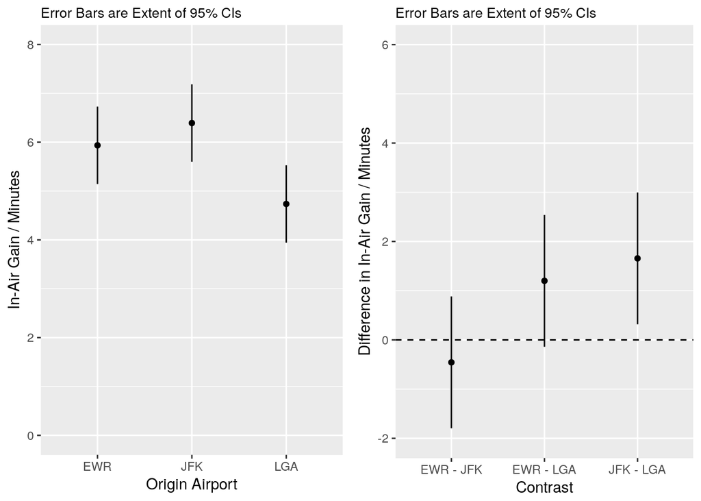

```r
p.gain <- ggplot(summary(m.gain.by.origin.emm), aes(x=origin, y=emmean, ymin=lower.CL, ymax=upper.CL)) + geom_point() + geom_linerange() + labs(x="Origin Airport", y="In-Air Gain / Minutes", subtitle="Error Bars are Extent of 95% CIs") + ylim(0,8)

p.contrasts <- ggplot(m.gain.by.origin.pairs, aes(x=contrast, y=estimate, ymin=lower.CL, ymax=upper.CL)) + geom_point() + geom_linerange() + geom_hline(yintercept=0, lty=2) + labs(x="Contrast", y="Difference in In-Air Gain / Minutes", subtitle="Error Bars are Extent of 95% CIs") + ylim(-2,6)

grid.arrange(p.gain, p.contrasts, ncol=2)
```

So we might write:

“The left panel of Figure X shows the mean daily in-air gain from each airport. JFK has the highest gain, followed by EWR. LGA has the lowest in-air gain. The right panel shows the estimates of the difference in in-air gain for each pair of airports. The estimate for the EWR-JFK comparison shows a point estimate of 0.5 minutes greater gain for JFK, but the 95% CI spans 0.9 minutes greater for EWR to 1.8 minutes greater for JFK…”

## The Underlying Model

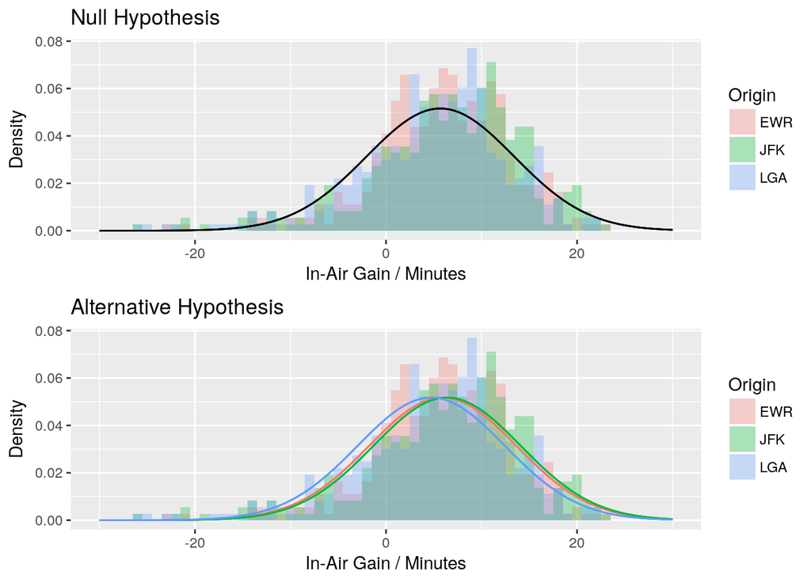

# In Air Gain, Controlling for Distance

Thus far, we have been rather naïve. The different airports fly to different destinations. Longer flights are probably more able to make up lost time in the air

Let’s work on the raw row-per-flight data so we can take the flight’s distance into account

The histogram of distance by origin shows that JFK and EWR do have many flights which fly much further than LGA

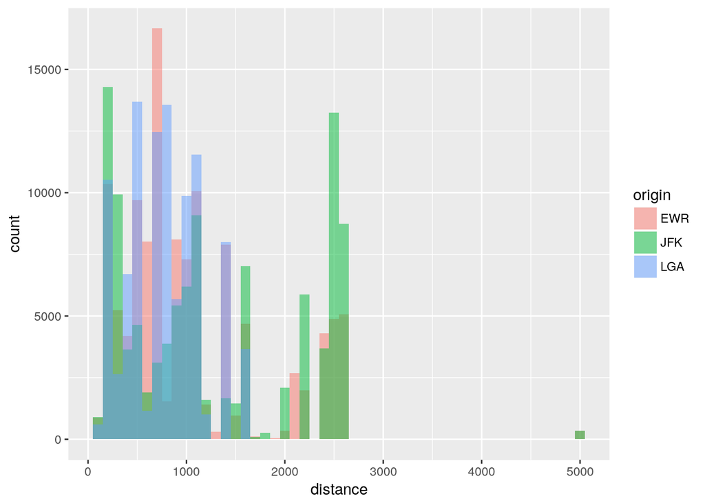

```r
ggplot(flights, aes(x=distance, fill=origin)) + geom_histogram(position="identity", alpha=0.5, binwidth=100)
```

```r
cor(select(flights, distance, gain))
```

```
##           distance      gain
## distance 1.0000000 0.1048957
## gain     0.1048957 1.0000000
```

This is a simple model with just gain as a function of origin:

```r
m.gain.by.origin <- lm(gain~origin, data=flights)
(  m.gain.by.origin.emm <- emmeans(m.gain.by.origin, ~origin)  )
```

```
##  origin   emmean         SE     df lower.CL upper.CL
##  EWR    5.902055 0.05266964 327343 5.798824 6.005286
##  JFK    6.472126 0.05457808 327343 6.365154 6.579097
##  LGA    4.503095 0.05667968 327343 4.392004 4.614185
##
## Confidence level used: 0.95
```

This model also includes the distance:

```r
m.gain.by.origin.distance <- lm(gain~origin+distance, data=flights)
(  m.gain.by.origin.distance.emm <- emmeans(m.gain.by.origin.distance, ~origin)  )
```

```
##  origin   emmean         SE     df lower.CL upper.CL
##  EWR    5.861797 0.05242798 327342 5.759039 5.964554
##  JFK    5.914636 0.05524088 327342 5.806365 6.022906
##  LGA    5.150967 0.05760607 327342 5.038060 5.263873
##
## Confidence level used: 0.95
```

This call to `anova()` compares the models and tests whether the more complicated model with distance fits *significantly* better

```r
anova(m.gain.by.origin, m.gain.by.origin.distance)
```

```
## Analysis of Variance Table
##
## Model 1: gain ~ origin
## Model 2: gain ~ origin + distance
##   Res.Df       RSS Df Sum of Sq      F    Pr(>F)
## 1 327343 106360599
## 2 327342 105366386  1    994214 3088.7 < 2.2e-16 ***
## ---
## Signif. codes:  0 '***' 0.001 '**' 0.01 '*' 0.05 '.' 0.1 ' ' 1
```

Here I have constructed a plot to highlight the importance of controlling for distance. Without control, in the univariate model, the differences in in-air gain are much larger. With control for distance, the EWR-JFK difference is nearly zero, and the difference to LGA is much smaller

The effect of origin in the multivariate model is *holding distance constant*

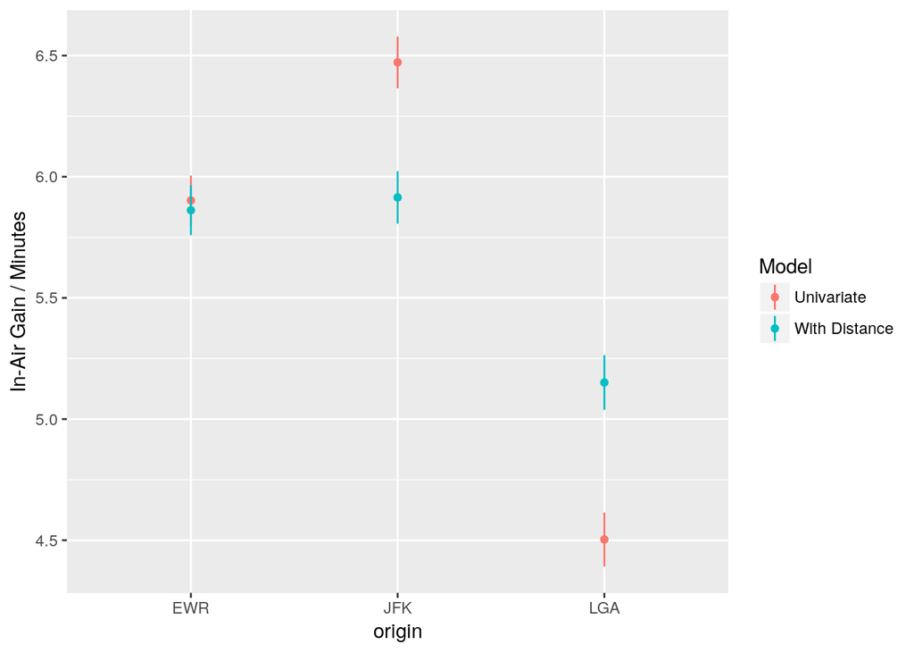

```r
m.gain.by.origin.emm.summary <- summary(m.gain.by.origin.emm)
m.gain.by.origin.emm.summary$model <- "Univariate"
m.gain.by.origin.distance.emm.summary <- summary(m.gain.by.origin.distance.emm)
m.gain.by.origin.distance.emm.summary$model <- "With Distance"
m.gain.two.models.emm.summary <- rbind(m.gain.by.origin.emm.summary, m.gain.by.origin.distance.emm.summary)

ggplot(m.gain.two.models.emm.summary, aes(x=origin, y=emmean, ymin=lower.CL, ymax=upper.CL, col=model)) + geom_point() + geom_linerange() + labs(x="origin", y="In-Air Gain / Minutes", col="Model")
```

# In Air Gain, By Origin and Day

Here we are going to explore how in-air gain varies by day, and whether effect of day varies across airports

Lets add a column indicating which day of the week it is

```r
flights <- flights %>% mutate(week_day=wday(time_hour, label=TRUE))
```

The term `origin*week_day` means `origin + week_day + origin:week_day`

The interaction term `origin:week_day` lets the effect of `week_day` differ across `origin` airport

```r
m.gain.by.origin.week_day <- lm(gain~origin*week_day, data=flights)
anova(m.gain.by.origin.week_day)
```

```
## Analysis of Variance Table
##
## Response: gain
##                     Df    Sum Sq Mean Sq F value    Pr(>F)
## origin               2    214174  107087 332.595 < 2.2e-16 ***
## week_day             6    621240  103540 321.578 < 2.2e-16 ***
## origin:week_day     12    348955   29080  90.316 < 2.2e-16 ***
## Residuals       327325 105390405     322
## ---
## Signif. codes:  0 '***' 0.001 '**' 0.01 '*' 0.05 '.' 0.1 ' ' 1
```

```r
(  m.gain.by.origin.week_day.emm <- emmeans(m.gain.by.origin.week_day, ~origin+week_day)  )
```

```
##  origin week_day   emmean        SE     df lower.CL  upper.CL
##  EWR    Sun      6.632612 0.1414510 327325 6.355373  6.909852
##  JFK    Sun      5.357284 0.1430830 327325 5.076845  5.637722
##  LGA    Sun      8.180609 0.1533758 327325 7.879997  8.481221
##  EWR    Mon      5.094868 0.1342410 327325 4.831759  5.357976
##  JFK    Mon      6.806719 0.1428651 327325 6.526708  7.086731
##  LGA    Mon      3.276263 0.1433933 327325 2.995216  3.557310
##  EWR    Tue      5.443367 0.1347320 327325 5.179296  5.707438
##  JFK    Tue      7.067840 0.1427430 327325 6.788067  7.347612
##  LGA    Tue      3.030453 0.1436734 327325 2.748857  3.312048
##  EWR    Wed      4.950235 0.1350905 327325 4.685462  5.215009
##  JFK    Wed      5.859264 0.1441734 327325 5.576688  6.141840
##  LGA    Wed      2.918317 0.1441316 327325 2.635824  3.200811
##  EWR    Thu      4.502378 0.1358394 327325 4.236137  4.768620
##  JFK    Thu      6.107895 0.1429513 327325 5.827715  6.388076
##  LGA    Thu      2.207546 0.1453511 327325 1.922662  2.492430
##  EWR    Fri      5.948110 0.1360970 327325 5.681364  6.214856
##  JFK    Fri      6.253204 0.1429240 327325 5.973077  6.533331
##  LGA    Fri      4.486611 0.1446599 327325 4.203082  4.770140
##  EWR    Sat      9.855202 0.1576433 327325 9.546226 10.164179
##  JFK    Sat      7.929708 0.1476607 327325 7.640297  8.219119
##  LGA    Sat      9.631417 0.1788029 327325 9.280968  9.981866
##
## Confidence level used: 0.95
```

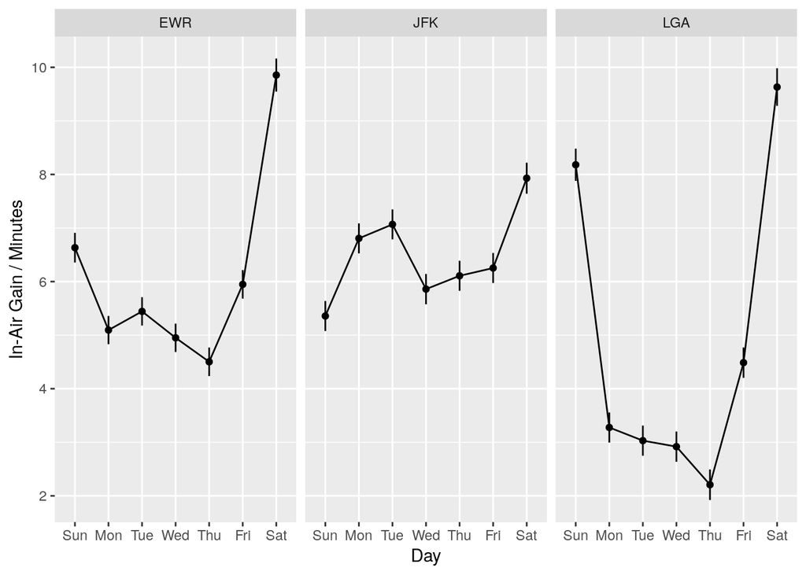

```r
ggplot(summary(m.gain.by.origin.week_day.emm), aes(x=week_day, y=emmean, ymin=lower.CL, ymax=upper.CL, group=origin)) + geom_point() + geom_linerange() + labs(x="Day", y="In-Air Gain / Minutes") + facet_grid(.~origin) + geom_line()
```

Interactions are tricky. You need to write about them very carefully. It is hard to explain that the effect of one variable depends on another

If we are NHSTing, we might write “The effect of day of the week on in-air gain differs across origin airports, $F(12, 327325) = 90.3$, $p<.0001$”

We could follow up the interaction with lots of pairwise comparisons, but unless we have some specific hypotheses about *why* we expect particular differences it is probably best just to describe the pattern in words: “While Saturday and Sunday, are weekdays with bigger in-air gains at EWR and LGA, the pattern at JFK is different: Saturday also has the biggest in-air gain at JFK, but Sunday has the lowest”

# References

Dalgaard, P. (2008) *Introductory statistics with R*. 2nd edn. New York: Springer.

Howell, D. C. (2017) *Fundamental statistics for the behavioral sciences*. 9th edn. Belmont, CA: Duxbury Press.